# Track Trends

Garrett Flores

2022-06-07

## Introduction

##### Track and Field has been experiencing some of the fastest recorded performances ever in the past couple years. This has been documents by the frequency or world and national records being set in various diciplines. It has widely been observed that track and field times have gradually gotten faster since times started being tracked over 100 years ago.

##### Is the same trend being observed at the olympics? Olympic races tend to be significantly slower than the current world record because of race tactics. This is expecially true for distance races 1500m-Marathon.

##### As a comparison, I looked at Mens 100m and 10000m times. In the 10000m distance, you expect race tactics to have a significant factor on the time outcome. However, in a 100m race, athletes go 100% from start to end with minimal focus on tactics.

##### The purpose of this analysis is to find out if olympic or tactical races are also getting faster as the years go by.

## Loading the Packages

```r
    library(tidyverse)
    library(janitor)
    library(lubridate)
    library(gapminder)
    library(ggpubr)
    library(dplyr)
```

## Loading the Data

```r
results <- read.csv('results.csv')

    head(results)
```

```
##   Gender      Event Location Year Medal                  Name Nationality
## 1      M 10000M Men      Rio 2016     G         Mohamed FARAH         USA
## 2      M 10000M Men      Rio 2016     S Paul Kipngetich TANUI         KEN
## 3      M 10000M Men      Rio 2016     B          Tamirat TOLA         ETH
## 4      M 10000M Men  Beijing 2008     G       Kenenisa BEKELE         ETH
## 5      M 10000M Men  Beijing 2008     S        Sileshi SIHINE         ETH
## 6      M 10000M Men  Beijing 2008     B            Micah KOGO         KEN
##     Result
## 1 25:05.17
## 2 27:05.64
## 3 27:06.26
## 4 27:01.17
## 5 27:02.77
## 6 27:04.11
```

##### We have track and field data from the Olympics going back over 100 years ago. Here we look and race time trends to see if their is any differences in finish times.

## Data Cleaning

```r
    results_mod <- results %>%
      filter(Event == '10000M Men') %>%
      arrange(Year) %>%
      mutate(Seconds = period_to_seconds(ms(Result))) %>%
      mutate(Pace = 10000 / Seconds ) %>%
      clean_names()
    results_mod
```

```
##    gender      event              location year medal                  name
## 1       M 10000M Men             Stockholm 1912     G    Hannes KOLEHMAINEN
## 2       M 10000M Men             Stockholm 1912     S        Lewis TEWANIMA
## 3       M 10000M Men             Stockholm 1912     B        Albin STENROOS
## 4       M 10000M Men               Antwerp 1920     G           Paavo NURMI
## 5       M 10000M Men               Antwerp 1920     S      Joseph GUILLEMOT
## 6       M 10000M Men               Antwerp 1920     B          James WILSON
## 7       M 10000M Men                 Paris 1924     G          Ville RITOLA
## 8       M 10000M Men                 Paris 1924     S            Edvin WIDE
## 9       M 10000M Men                 Paris 1924     B             Eero BERG
## 10      M 10000M Men             Amsterdam 1928     G           Paavo NURMI
## 11      M 10000M Men             Amsterdam 1928     S          Ville RITOLA
## 12      M 10000M Men             Amsterdam 1928     B            Edvin WIDE
## 13      M 10000M Men           Los Angeles 1932     G     Janusz KUSOCINSKI
## 14      M 10000M Men           Los Angeles 1932     S     Volmari ISO-HOLLO
```

[output cut: 125 more lines]

##### I first wanted to look at trends at the 10000m distance. First I filtered the data so that it would only see events equal to 10000m Men. To start off I wanted to arrange by year. I noticed that the Result column was in a date time format and was unable to graph properly. I decided to instead graph by pace. I did this by converting the date time values to seconds and then divided the distance by seconds to fill an additional column called Pace. Lastly, I reformated all the column names to so that they were lower case.

```r
results_mod_sprint <- results %>%
  arrange(Result) %>%
  filter(Event == '100M Men') %>%
  slice(1:80) %>%
  mutate(Result = as.numeric(Result)) %>%
  clean_names()
results_mod_sprint
```

```
##    gender    event              location year medal                     name
## 1       M 100M Men                Mexico 1968     S            Lennox MILLER
## 2       M 100M Men                Mexico 1968     B           Charlie GREENE
## 3       M 100M Men                 Tokyo 1964     G                Bob HAYES
## 4       M 100M Men             Barcelona 1992     S         Frank FREDERICKS
## 5       M 100M Men                Sydney 2000     B         Obadele THOMPSON
## 6       M 100M Men             Barcelona 1992     B          Dennis MITCHELL
## 7       M 100M Men              Montreal 1976     G          Hasely CRAWFORD
## 8       M 100M Men              Montreal 1976     S           Donald QUARRIE
## 9       M 100M Men              Montreal 1976     B            Valery BORZOV
## 10      M 100M Men                Munich 1972     G            Valery BORZOV
## 11      M 100M Men           Los Angeles 1984     S               Sam GRADDY
## 12      M 100M Men                  Rome 1960     G               Armin HARY
## 13      M 100M Men                  Rome 1960     S                Dave SIME
## 14      M 100M Men                 Tokyo 1964     S        Enrique FIGUEROLA
```

[output cut: 147 more lines]

##### A second dataset was needed to analysis trends from the 100m distance. Like with the previous data cleaning, I arranged and filtered the data so that it was organized by result and filtered by 100m Men. I then removed two rows that had ‘none’ as a value. Upon further investigation, the values in the Result column were character data types. I used the mutate function and as.numeric function to convert this column to a numeric data type. Lastly, I reformated the column names so that they were lower case.

## Visualization

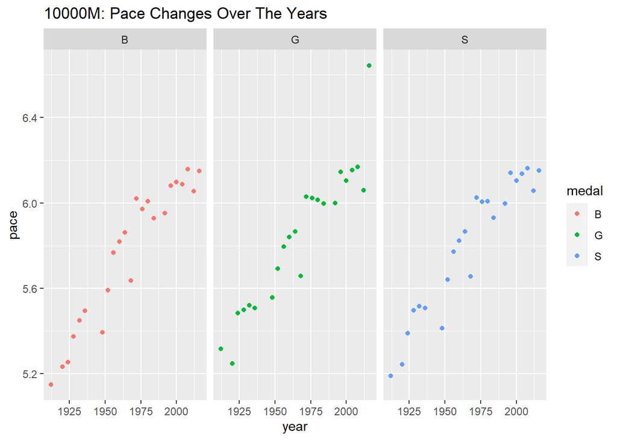

##### Above shows a multiple scatter plots showing 10000m paces by medal over the years. You can clearly see a postive relationship between pace and year for all three medals.

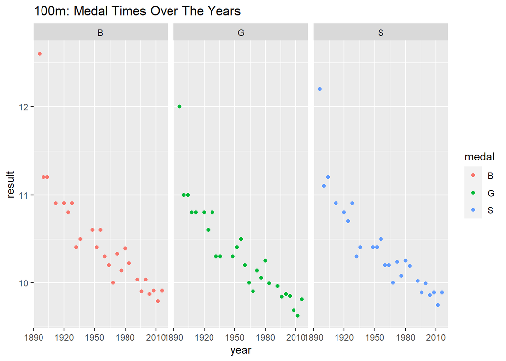

##### Above shows multiple scatter plots showing 100m times over the years. You can clearly see a negative correlation between finish time and year for all three medals.

## Conclusion

##### Based on the data provided, times during the olympics have indeed gotten faster in the 10000m and 100m distances, despite the use of race tactics in the 10000m.